# Risk Factor Analysis

## Outcome Variable

**Outcome Variable:** sstunted

## Predictor Variables

**Intervention Variable:** nrooms

**Adjustment Set:**

- arm
- sex
- W_mage
- meducyrs
- feducyrs
- hhwealth_quart
- hfoodsec
- W_mhtcm
- W_mwtkg
- W_mbmi
- W_nchldlt5
- W_parity
- impfloor
- impsan
- safeh20
- delta_W_mage
- delta_meducyrs
- delta_feducyrs
- delta_hhwealth_quart
- delta_hfoodsec
- delta_W_mhtcm
- delta_W_mwtkg
- delta_W_mbmi
- delta_W_nchldlt5
- delta_W_parity
- delta_impfloor
- delta_impsan
- delta_safeh20

## Stratifying Variables

The analysis was stratified on these variable(s):

- agecat
- studyid
- country

## Data Summary

| agecat | studyid | country | nrooms | sstunted | n_cell | n |
| --- | --- | --- | --- | --- | --- | --- |
| Birth | CMC-V-BCS-2002 | INDIA | 4+ | 0 | 5 | 92 |
| Birth | CMC-V-BCS-2002 | INDIA | 4+ | 1 | 0 | 92 |
| Birth | CMC-V-BCS-2002 | INDIA | 1 | 0 | 36 | 92 |
| Birth | CMC-V-BCS-2002 | INDIA | 1 | 1 | 2 | 92 |
| Birth | CMC-V-BCS-2002 | INDIA | 2 | 0 | 28 | 92 |
| Birth | CMC-V-BCS-2002 | INDIA | 2 | 1 | 1 | 92 |
| Birth | CMC-V-BCS-2002 | INDIA | 3 | 0 | 19 | 92 |
| Birth | CMC-V-BCS-2002 | INDIA | 3 | 1 | 1 | 92 |
| Birth | COHORTS | INDIA | 4+ | 0 | 91 | 4769 |
| Birth | COHORTS | INDIA | 4+ | 1 | 1 | 4769 |
| Birth | COHORTS | INDIA | 1 | 0 | 3021 | 4769 |
| Birth | COHORTS | INDIA | 1 | 1 | 104 | 4769 |
| Birth | COHORTS | INDIA | 2 | 0 | 1356 | 4769 |
| Birth | COHORTS | INDIA | 2 | 1 | 29 | 4769 |
| Birth | COHORTS | INDIA | 3 | 0 | 160 | 4769 |
| Birth | COHORTS | INDIA | 3 | 1 | 7 | 4769 |
| Birth | CONTENT | PERU | 4+ | 0 | 1 | 2 |
| Birth | CONTENT | PERU | 4+ | 1 | 0 | 2 |
| Birth | CONTENT | PERU | 1 | 0 | 0 | 2 |
| Birth | CONTENT | PERU | 1 | 1 | 0 | 2 |
| Birth | CONTENT | PERU | 2 | 0 | 1 | 2 |
| Birth | CONTENT | PERU | 2 | 1 | 0 | 2 |
| Birth | CONTENT | PERU | 3 | 0 | 0 | 2 |
| Birth | CONTENT | PERU | 3 | 1 | 0 | 2 |
| Birth | GMS-Nepal | NEPAL | 4+ | 0 | 306 | 696 |
| Birth | GMS-Nepal | NEPAL | 4+ | 1 | 15 | 696 |
| Birth | GMS-Nepal | NEPAL | 1 | 0 | 44 | 696 |
| Birth | GMS-Nepal | NEPAL | 1 | 1 | 5 | 696 |
| Birth | GMS-Nepal | NEPAL | 2 | 0 | 139 | 696 |
| Birth | GMS-Nepal | NEPAL | 2 | 1 | 6 | 696 |

[output cut: 354 more lines]

The following strata were considered:

- agecat: 24 months, studyid: CMC-V-BCS-2002, country: INDIA
- agecat: 24 months, studyid: COHORTS, country: INDIA
- agecat: 24 months, studyid: CONTENT, country: PERU
- agecat: 24 months, studyid: GMS-Nepal, country: NEPAL
- agecat: 24 months, studyid: IRC, country: INDIA
- agecat: 24 months, studyid: JiVitA-3, country: BANGLADESH
- agecat: 24 months, studyid: JiVitA-4, country: BANGLADESH
- agecat: 24 months, studyid: MAL-ED, country: BANGLADESH
- agecat: 24 months, studyid: MAL-ED, country: BRAZIL
- agecat: 24 months, studyid: MAL-ED, country: INDIA
- agecat: 24 months, studyid: MAL-ED, country: NEPAL
- agecat: 24 months, studyid: MAL-ED, country: PERU
- agecat: 24 months, studyid: MAL-ED, country: SOUTH AFRICA
- agecat: 24 months, studyid: MAL-ED, country: TANZANIA, UNITED REPUBLIC OF
- agecat: 24 months, studyid: NIH-Crypto, country: BANGLADESH
- agecat: 24 months, studyid: PROVIDE, country: BANGLADESH
- agecat: 6 months, studyid: CMC-V-BCS-2002, country: INDIA
- agecat: 6 months, studyid: COHORTS, country: INDIA
- agecat: 6 months, studyid: CONTENT, country: PERU
- agecat: 6 months, studyid: GMS-Nepal, country: NEPAL
- agecat: 6 months, studyid: IRC, country: INDIA
- agecat: 6 months, studyid: JiVitA-3, country: BANGLADESH
- agecat: 6 months, studyid: JiVitA-4, country: BANGLADESH
- agecat: 6 months, studyid: MAL-ED, country: BANGLADESH
- agecat: 6 months, studyid: MAL-ED, country: BRAZIL
- agecat: 6 months, studyid: MAL-ED, country: INDIA
- agecat: 6 months, studyid: MAL-ED, country: NEPAL
- agecat: 6 months, studyid: MAL-ED, country: PERU
- agecat: 6 months, studyid: MAL-ED, country: SOUTH AFRICA
- agecat: 6 months, studyid: MAL-ED, country: TANZANIA, UNITED REPUBLIC OF
- agecat: 6 months, studyid: NIH-Crypto, country: BANGLADESH
- agecat: 6 months, studyid: PROVIDE, country: BANGLADESH
- agecat: Birth, studyid: CMC-V-BCS-2002, country: INDIA
- agecat: Birth, studyid: COHORTS, country: INDIA
- agecat: Birth, studyid: CONTENT, country: PERU
- agecat: Birth, studyid: GMS-Nepal, country: NEPAL
- agecat: Birth, studyid: IRC, country: INDIA
- agecat: Birth, studyid: JiVitA-3, country: BANGLADESH
- agecat: Birth, studyid: JiVitA-4, country: BANGLADESH
- agecat: Birth, studyid: MAL-ED, country: BANGLADESH
- agecat: Birth, studyid: MAL-ED, country: BRAZIL
- agecat: Birth, studyid: MAL-ED, country: INDIA
- agecat: Birth, studyid: MAL-ED, country: NEPAL
- agecat: Birth, studyid: MAL-ED, country: PERU
- agecat: Birth, studyid: MAL-ED, country: SOUTH AFRICA
- agecat: Birth, studyid: MAL-ED, country: TANZANIA, UNITED REPUBLIC OF
- agecat: Birth, studyid: NIH-Crypto, country: BANGLADESH
- agecat: Birth, studyid: PROVIDE, country: BANGLADESH

### Dropped Strata

Some strata were dropped due to rare outcomes:

- agecat: Birth, studyid: CMC-V-BCS-2002, country: INDIA
- agecat: Birth, studyid: COHORTS, country: INDIA
- agecat: Birth, studyid: CONTENT, country: PERU
- agecat: Birth, studyid: IRC, country: INDIA
- agecat: Birth, studyid: MAL-ED, country: BANGLADESH
- agecat: Birth, studyid: MAL-ED, country: BRAZIL
- agecat: Birth, studyid: MAL-ED, country: INDIA
- agecat: Birth, studyid: MAL-ED, country: NEPAL
- agecat: Birth, studyid: MAL-ED, country: PERU
- agecat: Birth, studyid: MAL-ED, country: SOUTH AFRICA
- agecat: Birth, studyid: MAL-ED, country: TANZANIA, UNITED REPUBLIC OF
- agecat: Birth, studyid: NIH-Crypto, country: BANGLADESH
- agecat: Birth, studyid: PROVIDE, country: BANGLADESH
- agecat: 6 months, studyid: CMC-V-BCS-2002, country: INDIA
- agecat: 6 months, studyid: COHORTS, country: INDIA
- agecat: 6 months, studyid: CONTENT, country: PERU
- agecat: 6 months, studyid: GMS-Nepal, country: NEPAL
- agecat: 6 months, studyid: IRC, country: INDIA
- agecat: 6 months, studyid: MAL-ED, country: BANGLADESH
- agecat: 6 months, studyid: MAL-ED, country: BRAZIL
- agecat: 6 months, studyid: MAL-ED, country: INDIA
- agecat: 6 months, studyid: MAL-ED, country: NEPAL
- agecat: 6 months, studyid: MAL-ED, country: PERU
- agecat: 6 months, studyid: MAL-ED, country: SOUTH AFRICA
- agecat: 6 months, studyid: MAL-ED, country: TANZANIA, UNITED REPUBLIC OF
- agecat: 6 months, studyid: NIH-Crypto, country: BANGLADESH
- agecat: 6 months, studyid: PROVIDE, country: BANGLADESH
- agecat: 24 months, studyid: CMC-V-BCS-2002, country: INDIA
- agecat: 24 months, studyid: CONTENT, country: PERU
- agecat: 24 months, studyid: IRC, country: INDIA
- agecat: 24 months, studyid: MAL-ED, country: BANGLADESH
- agecat: 24 months, studyid: MAL-ED, country: BRAZIL
- agecat: 24 months, studyid: MAL-ED, country: INDIA
- agecat: 24 months, studyid: MAL-ED, country: NEPAL
- agecat: 24 months, studyid: MAL-ED, country: PERU
- agecat: 24 months, studyid: MAL-ED, country: SOUTH AFRICA
- agecat: 24 months, studyid: MAL-ED, country: TANZANIA, UNITED REPUBLIC OF
- agecat: 24 months, studyid: NIH-Crypto, country: BANGLADESH
- agecat: 24 months, studyid: PROVIDE, country: BANGLADESH

## Methods Detail

We’re interested in the causal parameters $E[Y_a]$ for all values of $a \in \mathcal{A}$. These parameters represent the mean outcome if, possibly contrary to fact, we intervened to set all units to have $A=a$. Under the randomization and positivity assumptions, these are identified by the statistical parameters $\psi_a=E_W[E_{Y|A,W}(Y|A=a,W)]$. In addition, we’re interested in the mean of $Y$, $E[Y]$ under no intervention (the observed mean). We will estimate these parameters by using SuperLearner to fit the relevant likelihood factors – $E_{Y|A,W}(Y|A=a,W)$ and $p(A=a|W)$, and then updating our likelihood fit using a joint TMLE.

For unadjusted analyses ($W=\{\}$), initial likelihoods were estimated using Lrnr_glm to estimate the simple $E(Y|A)$ and Lrnr_mean to estimate $p(A)$. For adjusted analyses, a small library containing Lrnr_glmnet, Lrnr_xgboost, and Lrnr_mean was used.

Having estimated these parameters, we will then use the delta method to estimate relative risks and attributable risks relative to a prespecified baseline level of $A$.

# Results Detail

## Results Plots

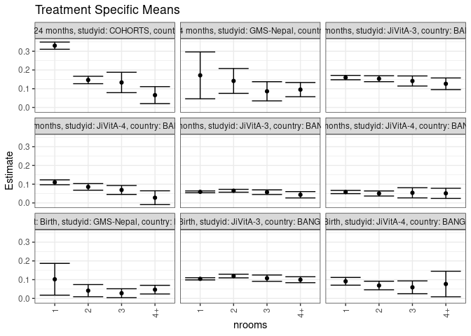

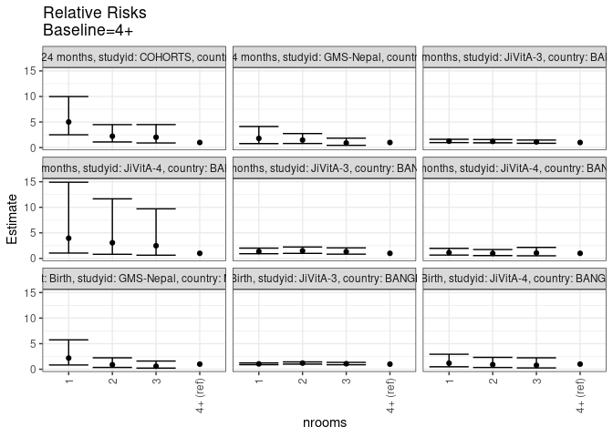

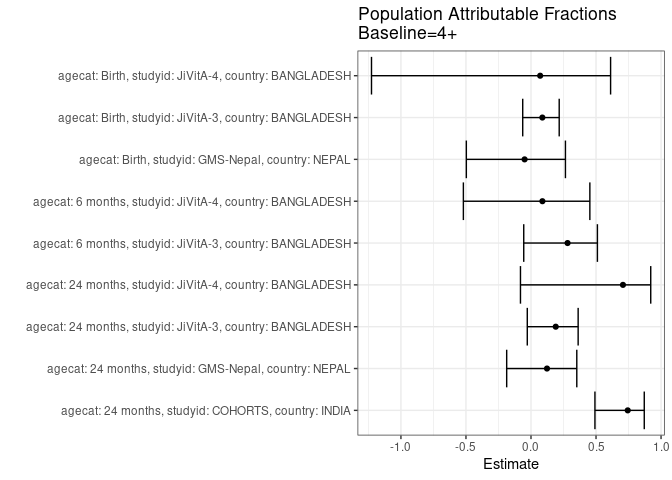

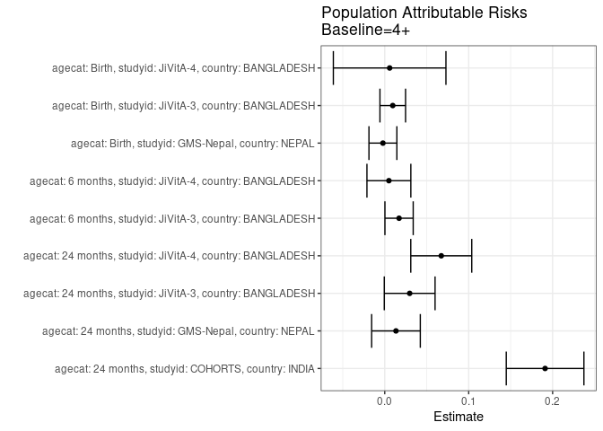

## Results Table

### Parameter: TSM

| agecat | studyid | country | intervention_level | baseline_level | estimate | ci_lower | ci_upper |
| --- | --- | --- | --- | --- | --- | --- | --- |
| Birth | GMS-Nepal | NEPAL | 4+ | NA | 0.0467290 | 0.0236238 | 0.0698341 |
| Birth | GMS-Nepal | NEPAL | 1 | NA | 0.1020408 | 0.0172249 | 0.1868568 |
| Birth | GMS-Nepal | NEPAL | 2 | NA | 0.0413793 | 0.0089385 | 0.0738201 |
| Birth | GMS-Nepal | NEPAL | 3 | NA | 0.0276243 | 0.0037306 | 0.0515180 |
| Birth | JiVitA-3 | BANGLADESH | 4+ | NA | 0.0996107 | 0.0838118 | 0.1154097 |
| Birth | JiVitA-3 | BANGLADESH | 1 | NA | 0.1044130 | 0.0986406 | 0.1101854 |
| Birth | JiVitA-3 | BANGLADESH | 2 | NA | 0.1193965 | 0.1096364 | 0.1291566 |
| Birth | JiVitA-3 | BANGLADESH | 3 | NA | 0.1078105 | 0.0908022 | 0.1248188 |
| Birth | JiVitA-4 | BANGLADESH | 4+ | NA | 0.0767903 | 0.0086417 | 0.1449389 |
| Birth | JiVitA-4 | BANGLADESH | 1 | NA | 0.0912193 | 0.0705657 | 0.1118730 |
| Birth | JiVitA-4 | BANGLADESH | 2 | NA | 0.0688603 | 0.0460202 | 0.0917004 |
| Birth | JiVitA-4 | BANGLADESH | 3 | NA | 0.0591268 | 0.0250030 | 0.0932506 |
| 6 months | JiVitA-3 | BANGLADESH | 4+ | NA | 0.0435988 | 0.0267159 | 0.0604818 |
| 6 months | JiVitA-3 | BANGLADESH | 1 | NA | 0.0591691 | 0.0543290 | 0.0640092 |
| 6 months | JiVitA-3 | BANGLADESH | 2 | NA | 0.0648200 | 0.0571181 | 0.0725219 |
| 6 months | JiVitA-3 | BANGLADESH | 3 | NA | 0.0573743 | 0.0451406 | 0.0696081 |
| 6 months | JiVitA-4 | BANGLADESH | 4+ | NA | 0.0512311 | 0.0242086 | 0.0782537 |
| 6 months | JiVitA-4 | BANGLADESH | 1 | NA | 0.0581508 | 0.0496749 | 0.0666266 |
| 6 months | JiVitA-4 | BANGLADESH | 2 | NA | 0.0503147 | 0.0367760 | 0.0638534 |
| 6 months | JiVitA-4 | BANGLADESH | 3 | NA | 0.0540646 | 0.0269194 | 0.0812098 |
| 24 months | COHORTS | INDIA | 4+ | NA | 0.0657895 | 0.0205512 | 0.1110277 |
| 24 months | COHORTS | INDIA | 1 | NA | 0.3297086 | 0.3104894 | 0.3489277 |
| 24 months | COHORTS | INDIA | 2 | NA | 0.1466011 | 0.1267588 | 0.1664435 |
| 24 months | COHORTS | INDIA | 3 | NA | 0.1333333 | 0.0789262 | 0.1877405 |
| 24 months | GMS-Nepal | NEPAL | 4+ | NA | 0.0952381 | 0.0573450 | 0.1331312 |
| 24 months | GMS-Nepal | NEPAL | 1 | NA | 0.1714286 | 0.0464412 | 0.2964159 |
| 24 months | GMS-Nepal | NEPAL | 2 | NA | 0.1415094 | 0.0750891 | 0.2079298 |
| 24 months | GMS-Nepal | NEPAL | 3 | NA | 0.0862069 | 0.0350788 | 0.1373350 |
| 24 months | JiVitA-3 | BANGLADESH | 4+ | NA | 0.1263407 | 0.0952672 | 0.1574142 |
| 24 months | JiVitA-3 | BANGLADESH | 1 | NA | 0.1595180 | 0.1478497 | 0.1711864 |
| 24 months | JiVitA-3 | BANGLADESH | 2 | NA | 0.1533387 | 0.1374881 | 0.1691893 |
| 24 months | JiVitA-3 | BANGLADESH | 3 | NA | 0.1412288 | 0.1143704 | 0.1680871 |
| 24 months | JiVitA-4 | BANGLADESH | 4+ | NA | 0.0278884 | -0.0089281 | 0.0647049 |
| 24 months | JiVitA-4 | BANGLADESH | 1 | NA | 0.1100753 | 0.0970601 | 0.1230905 |
| 24 months | JiVitA-4 | BANGLADESH | 2 | NA | 0.0855263 | 0.0679585 | 0.1030942 |
| 24 months | JiVitA-4 | BANGLADESH | 3 | NA | 0.0692464 | 0.0454346 | 0.0930583 |

### Parameter: E(Y)

| agecat | studyid | country | intervention_level | baseline_level | estimate | ci_lower | ci_upper |
| --- | --- | --- | --- | --- | --- | --- | --- |
| Birth | GMS-Nepal | NEPAL | NA | NA | 0.0445402 | 0.0292033 | 0.0598771 |
| Birth | JiVitA-3 | BANGLADESH | NA | NA | 0.1091444 | 0.1045855 | 0.1137033 |
| Birth | JiVitA-4 | BANGLADESH | NA | NA | 0.0826241 | 0.0709364 | 0.0943118 |
| 6 months | JiVitA-3 | BANGLADESH | NA | NA | 0.0606548 | 0.0568001 | 0.0645094 |
| 6 months | JiVitA-4 | BANGLADESH | NA | NA | 0.0561658 | 0.0493946 | 0.0629370 |
| 24 months | COHORTS | INDIA | NA | NA | 0.2568073 | 0.2428154 | 0.2707992 |
| 24 months | GMS-Nepal | NEPAL | NA | NA | 0.1086066 | 0.0809724 | 0.1362407 |
| 24 months | JiVitA-3 | BANGLADESH | NA | NA | 0.1560325 | 0.1472890 | 0.1647760 |
| 24 months | JiVitA-4 | BANGLADESH | NA | NA | 0.0952180 | 0.0856733 | 0.1047628 |

### Parameter: RR

| agecat | studyid | country | intervention_level | baseline_level | estimate | ci_lower | ci_upper |
| --- | --- | --- | --- | --- | --- | --- | --- |
| Birth | GMS-Nepal | NEPAL | 4+ | 4+ | 1.0000000 | 1.0000000 | 1.000000 |
| Birth | GMS-Nepal | NEPAL | 1 | 4+ | 2.1836735 | 0.8301606 | 5.743984 |
| Birth | GMS-Nepal | NEPAL | 2 | 4+ | 0.8855172 | 0.3504743 | 2.237370 |
| Birth | GMS-Nepal | NEPAL | 3 | 4+ | 0.5911602 | 0.2182807 | 1.601014 |
| Birth | JiVitA-3 | BANGLADESH | 4+ | 4+ | 1.0000000 | 1.0000000 | 1.000000 |
| Birth | JiVitA-3 | BANGLADESH | 1 | 4+ | 1.0482104 | 0.8937231 | 1.229402 |
| Birth | JiVitA-3 | BANGLADESH | 2 | 4+ | 1.1986305 | 1.0044984 | 1.430281 |
| Birth | JiVitA-3 | BANGLADESH | 3 | 4+ | 1.0823179 | 0.8755325 | 1.337942 |
| Birth | JiVitA-4 | BANGLADESH | 4+ | 4+ | 1.0000000 | 1.0000000 | 1.000000 |
| Birth | JiVitA-4 | BANGLADESH | 1 | 4+ | 1.1879019 | 0.4810806 | 2.933211 |
| Birth | JiVitA-4 | BANGLADESH | 2 | 4+ | 0.8967314 | 0.3467086 | 2.319317 |
| Birth | JiVitA-4 | BANGLADESH | 3 | 4+ | 0.7699777 | 0.2647731 | 2.239146 |
| 6 months | JiVitA-3 | BANGLADESH | 4+ | 4+ | 1.0000000 | 1.0000000 | 1.000000 |
| 6 months | JiVitA-3 | BANGLADESH | 1 | 4+ | 1.3571259 | 0.9142464 | 2.014545 |
| 6 months | JiVitA-3 | BANGLADESH | 2 | 4+ | 1.4867371 | 0.9899476 | 2.232833 |
| 6 months | JiVitA-3 | BANGLADESH | 3 | 4+ | 1.3159601 | 0.8376126 | 2.067484 |
| 6 months | JiVitA-4 | BANGLADESH | 4+ | 4+ | 1.0000000 | 1.0000000 | 1.000000 |
| 6 months | JiVitA-4 | BANGLADESH | 1 | 4+ | 1.1350672 | 0.6550879 | 1.966725 |
| 6 months | JiVitA-4 | BANGLADESH | 2 | 4+ | 0.9821116 | 0.5541894 | 1.740458 |
| 6 months | JiVitA-4 | BANGLADESH | 3 | 4+ | 1.0553079 | 0.5163945 | 2.156636 |
| 24 months | COHORTS | INDIA | 4+ | 4+ | 1.0000000 | 1.0000000 | 1.000000 |
| 24 months | COHORTS | INDIA | 1 | 4+ | 5.0115702 | 2.5134637 | 9.992520 |
| 24 months | COHORTS | INDIA | 2 | 4+ | 2.2283374 | 1.1056576 | 4.490981 |
| 24 months | COHORTS | INDIA | 3 | 4+ | 2.0266667 | 0.9110212 | 4.508542 |
| 24 months | GMS-Nepal | NEPAL | 4+ | 4+ | 1.0000000 | 1.0000000 | 1.000000 |
| 24 months | GMS-Nepal | NEPAL | 1 | 4+ | 1.8000000 | 0.7844243 | 4.130418 |
| 24 months | GMS-Nepal | NEPAL | 2 | 4+ | 1.4858491 | 0.8030562 | 2.749182 |
| 24 months | GMS-Nepal | NEPAL | 3 | 4+ | 0.9051724 | 0.4431652 | 1.848830 |
| 24 months | JiVitA-3 | BANGLADESH | 4+ | 4+ | 1.0000000 | 1.0000000 | 1.000000 |
| 24 months | JiVitA-3 | BANGLADESH | 1 | 4+ | 1.2626020 | 0.9801468 | 1.626454 |
| 24 months | JiVitA-3 | BANGLADESH | 2 | 4+ | 1.2136919 | 0.9387308 | 1.569191 |
| 24 months | JiVitA-3 | BANGLADESH | 3 | 4+ | 1.1178404 | 0.8444189 | 1.479795 |
| 24 months | JiVitA-4 | BANGLADESH | 4+ | 4+ | 1.0000000 | 1.0000000 | 1.000000 |
| 24 months | JiVitA-4 | BANGLADESH | 1 | 4+ | 3.9469856 | 1.0452081 | 14.904874 |
| 24 months | JiVitA-4 | BANGLADESH | 2 | 4+ | 3.0667293 | 0.8069311 | 11.655059 |
| 24 months | JiVitA-4 | BANGLADESH | 3 | 4+ | 2.4829793 | 0.6354707 | 9.701764 |

### Parameter: PAR

| agecat | studyid | country | intervention_level | baseline_level | estimate | ci_lower | ci_upper |
| --- | --- | --- | --- | --- | --- | --- | --- |
| Birth | GMS-Nepal | NEPAL | 4+ | NA | -0.0021887 | -0.0188213 | 0.0144438 |
| Birth | JiVitA-3 | BANGLADESH | 4+ | NA | 0.0095337 | -0.0057230 | 0.0247903 |
| Birth | JiVitA-4 | BANGLADESH | 4+ | NA | 0.0058338 | -0.0612374 | 0.0729050 |
| 6 months | JiVitA-3 | BANGLADESH | 4+ | NA | 0.0170559 | 0.0002169 | 0.0338950 |
| 6 months | JiVitA-4 | BANGLADESH | 4+ | NA | 0.0049347 | -0.0212156 | 0.0310849 |
| 24 months | COHORTS | INDIA | 4+ | NA | 0.1910178 | 0.1447582 | 0.2372773 |
| 24 months | GMS-Nepal | NEPAL | 4+ | NA | 0.0133685 | -0.0156169 | 0.0423538 |
| 24 months | JiVitA-3 | BANGLADESH | 4+ | NA | 0.0296918 | -0.0005657 | 0.0599493 |
| 24 months | JiVitA-4 | BANGLADESH | 4+ | NA | 0.0673296 | 0.0310038 | 0.1036554 |

### Parameter: PAF

| agecat | studyid | country | intervention_level | baseline_level | estimate | ci_lower | ci_upper |
| --- | --- | --- | --- | --- | --- | --- | --- |
| Birth | GMS-Nepal | NEPAL | 4+ | NA | -0.0491408 | -0.4971711 | 0.2648159 |
| Birth | JiVitA-3 | BANGLADESH | 4+ | NA | 0.0873491 | -0.0636428 | 0.2169066 |
| Birth | JiVitA-4 | BANGLADESH | 4+ | NA | 0.0706066 | -1.2262946 | 0.6120136 |
| 6 months | JiVitA-3 | BANGLADESH | 4+ | NA | 0.2811969 | -0.0557946 | 0.5106265 |
| 6 months | JiVitA-4 | BANGLADESH | 4+ | NA | 0.0878591 | -0.5198714 | 0.4525847 |
| 24 months | COHORTS | INDIA | 4+ | NA | 0.7438177 | 0.4916036 | 0.8709091 |
| 24 months | GMS-Nepal | NEPAL | 4+ | NA | 0.1230907 | -0.1868964 | 0.3521171 |
| 24 months | JiVitA-3 | BANGLADESH | 4+ | NA | 0.1902922 | -0.0285131 | 0.3625490 |
| 24 months | JiVitA-4 | BANGLADESH | 4+ | NA | 0.7071096 | -0.0808982 | 0.9206357 |